# Short-term forgetting in sentence comprehension: Crosslinguistic evidence from verb-ﬁnal structures

**This file contains the analysis for the paper [Short-term forgetting in sentence comprehension: Crosslinguistic evidence from verb-ﬁnal structures](https://www.tandfonline.com/doi/abs/10.1080/01690960903310587). Language and Cognitive Processes. 2010. The authors are Shravan Vasishth, Katja Suckow, Richard L. Lewis, and Sabine Kern.**

**The current analysis was done by Himanshu Yadav (PhD student, University of Potsdam. hyadav@uni-potsdam.de. The results of this analysis may differ from the results reported in the paper.)**

## 1. Introduction

In an offline accuracy rating study on English double center-embedding constructions, Gibson and Thomas (1999) found that grammatical construtions (e.g., 1a) were less acceptable than ungrammatical constructions (e.g., 1b) where a middle verb phrase (e.g., $\textit{was cleaning every week})$ was missing.

1. The apartment that the maid who the service had sent over was cleaning every week was well decorated.
2. *The apartment that the maid who the service had sent over — was well decorated

Based on these results, Gibson and Thomas (1999) proposed that working-memory overload leads the comprehender to forget the prediction of the upcoming verb phrase (VP), which reduces working-memory load. This was called *VP-forgetting hypothesis*.

*VP-forgetting hypothesis* would predict faster processing times in the ungrammatical conditions where a verb-phrase is missing.

## 2. Experiment 1

Experiment 1 was an SPR study on English double center-embedding constructions. Consider example (2).

1. The carpenter who the craftsman that the peasant carried hurt $supervised_{_{V1}}$ the apprentice.
2. The carpenter who the pillar that the peasant carried hurt $supervised_{_{V1}}$ the apprentice.
3. *The carpenter who the craftsman that the peasant carried – $supervised_{_{V1}}$ the apprentice.
4. *The carpenter who the pillar that the peasant carried – $supervised_{_{V1}}$ the apprentice.

*VP-forgetting hypothesis* predicts that Grammatical conditions would have slower processing times compared to ungrammatical consitions where a middle VP is missing. In particular, a slowdown is expected at V1 and postV1 in condition 2-a and 2-b compared to condition 2-c and 2-d.

In addition, I also test the effect of interference. 2-a and 2-c are high-interference conditions and 2-b and 2-d are low-interference conditions. Because high-memory load in high-interference condition, *VP-forgetting hypothesis* would predict larger effect of grammaticality in high-interference condition – such that difference in reading times between grammatical and ungrammatical condition is higher in high-interference condition compared to low-interference condition.

**Note that in the paper, the authors report the effect of grammaticality only.**

### 2.1 Load the data

```
##   subject expt item condition position    word measure value  roi gram intf
## 1       1  gug   14         b        1     The      rt   354  NP1    1   -1
## 2       1  gug   14         b        2 defence      rt   330  NP1    1   -1
## 3       1  gug   14         b        3     who      rt   425  who    1   -1
## 4       1  gug   14         b        4     the      rt   386  NP2    1   -1
## 5       1  gug   14         b        5   knife      rt   402  NP2    1   -1
## 6       1  gug   14         b        6    that      rt   473 that    1   -1
```

### 2.2 Visualize the data

#### 2.2.1 Mean and Confidence interval in grammatical vs. Ungrammatical conditions

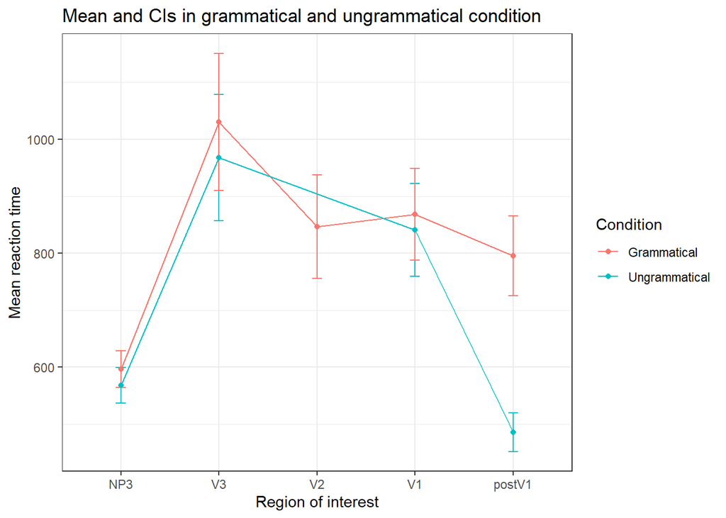

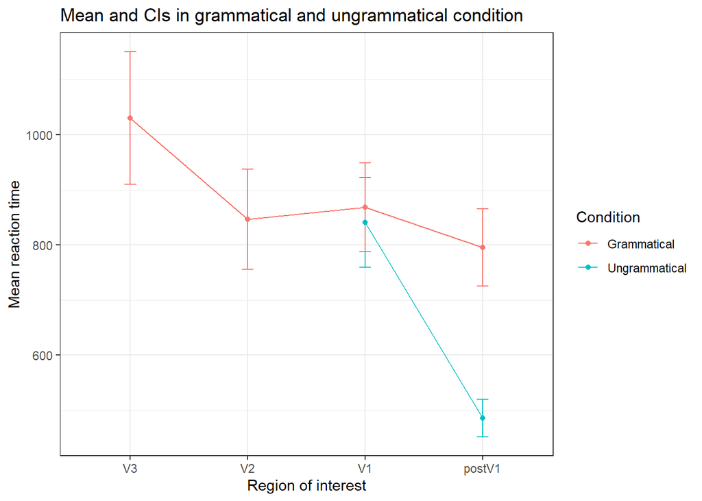

**The plot shows speed-up in ungrammatical conditions. This will be tested formally using a mixed-effect linear model**

#### 2.2.2 Mean and Confidence interval in high vs. low interference conditions

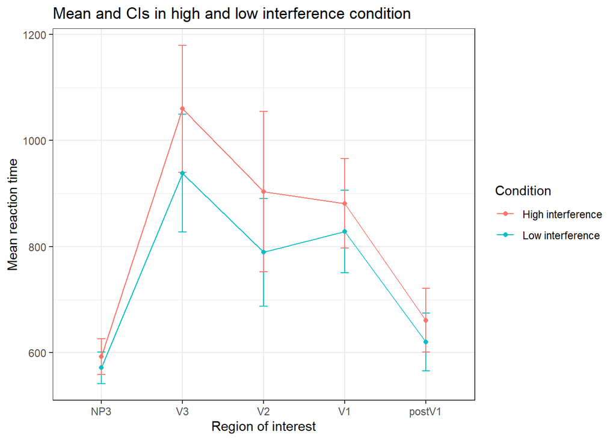

#### 2.2.3 Visualize by-subject data

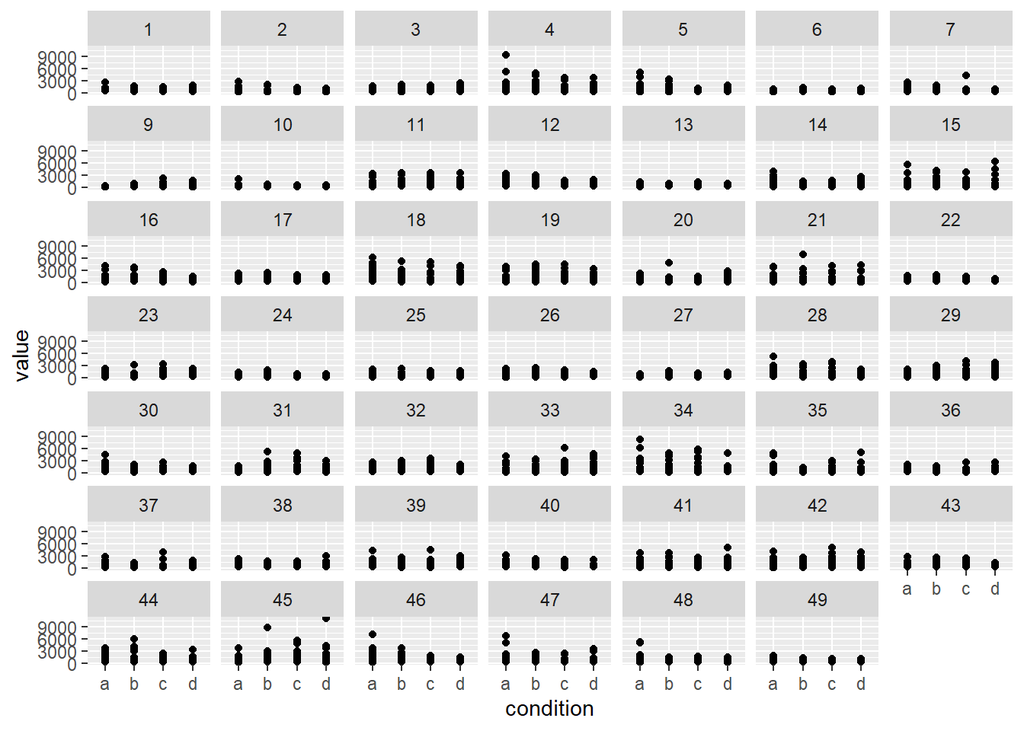

#### 2.2.4 Visualize by-item data

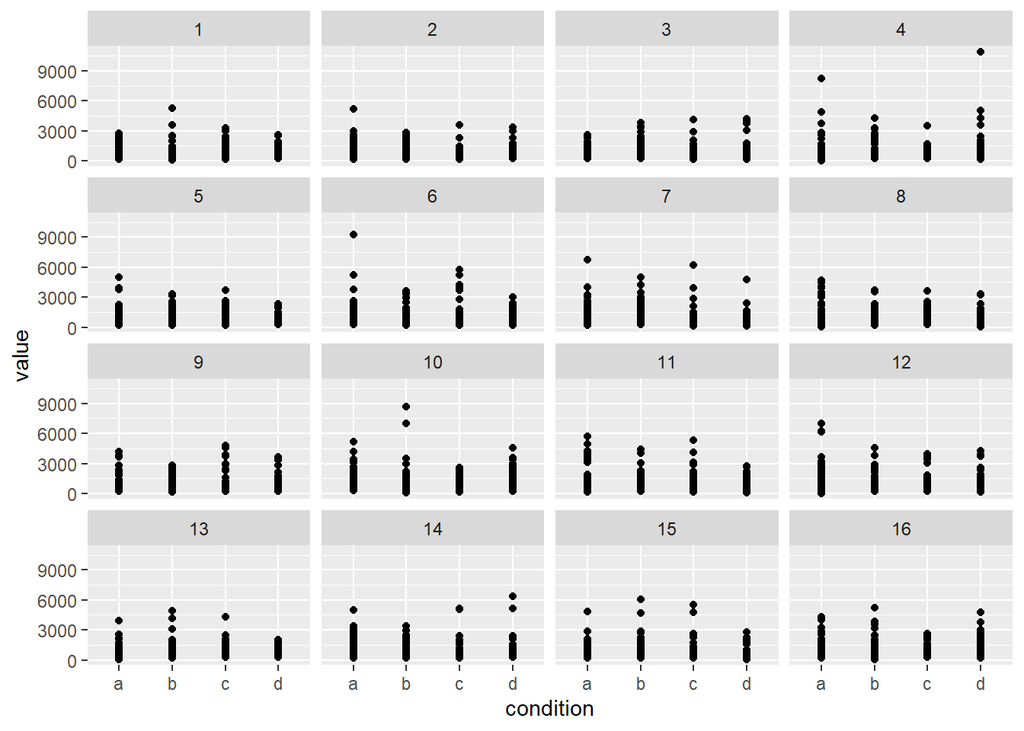

### 2.3 Analysis with linear mixed-effect models

As mentioned earlier, we are interested in reaction times at the V1 and postV1 region. Let’s us first test the interaction between grammaticality and interference at the V1 region.

#### 2.3.1 at V1: interaction effect (grammaticality x interference)

We fit the following regression: *let i be the index for the subject and j be the index for items*

$$\begin{equation}
log(rt_{ij}) = (\beta_0+u_{0i}+w_{0j}) + (\beta_1+u_{1i}+w_{1j}) Gram_{ij} + (\beta_2+u_{2i}+w_{2j}) Intf_{ij} + (\beta_{3}+u_{3i}+w_{3j}) Gram_{ij}*Intf_{ij} + \epsilon_{ij}
\end{equation}$$

**Predictions**

*Verb-forgetting hypothesis* would predict:

1. Main effect of grammaticality such that $\hat{\beta_1}$ is positive.
2. Interaction effect of interference and grammaticality such that difference in reading times between grammatical and ungrammatical condition is larger in high-interference condition compared to low-interference condition. Positive sign is expected for the $\hat{\beta_3}$.

**Results**

```r
data.V1 <- subset(data.m,roi=='V1')
mod.e1.1 <- lmer(log(value)~gram*intf+(1+gram*intf|subject)+(1+gram*intf|item),data=data.V1, control=lmerControl(optCtrl=list(maxfun=1e5)), REML = FALSE)
#save(mod.e1.1,'models/E1_V1_gramxintf.Rda')
```

1. Fixed effect estimates

```r
apa_table(
  as.data.frame(summary(mod.e1.1)$coefficients)
  , caption = "Estimated effect of grammaticality and interference at V1 region"
  , escape = FALSE
)
```

(#tab:unnamed-chunk-8)

*Estimated effect of grammaticality and interference at V1 region*

|  | Estimate | Std. Error | t value |
| --- | --- | --- | --- |
| (Intercept) | 6.49 | 0.06 | 112.54 |
| gram | 0.01 | 0.02 | 0.37 |
| intf | 0.02 | 0.02 | 0.91 |
| gram:intf | -0.01 | 0.02 | -0.27 |

**No effect of grammaticality at V1 region and no interaction effect**

2. Residuals

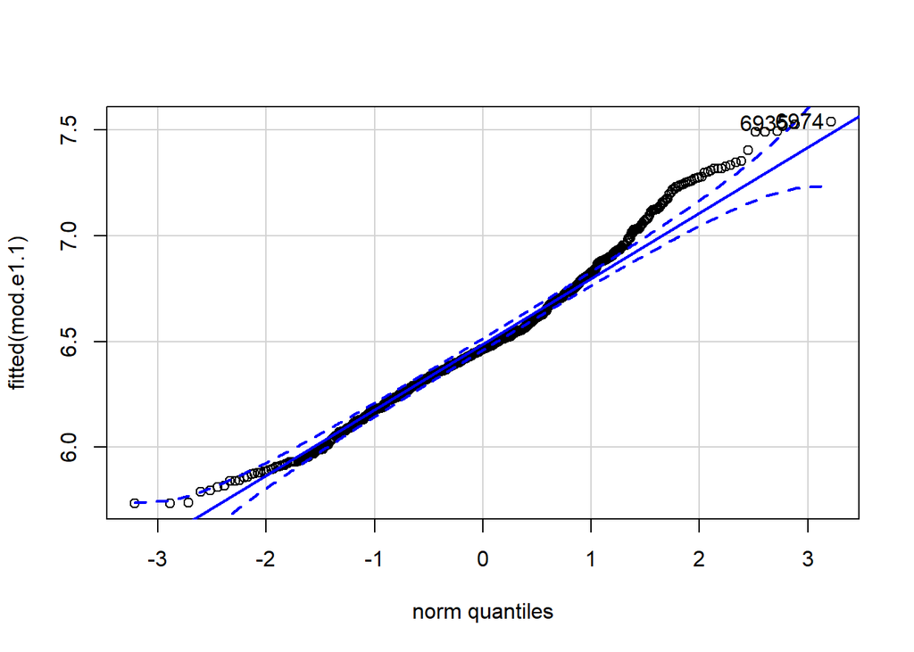

```
## 6974 6935
##  542  539
```

```r
# Let's check the residuals
qqPlot(fitted(mod.e1.1))
```

3. Participant-level differences

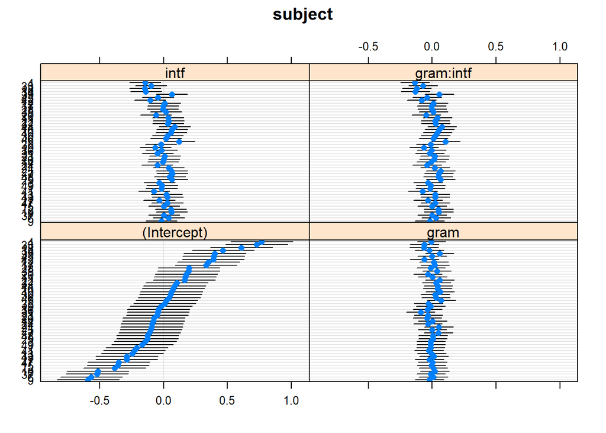

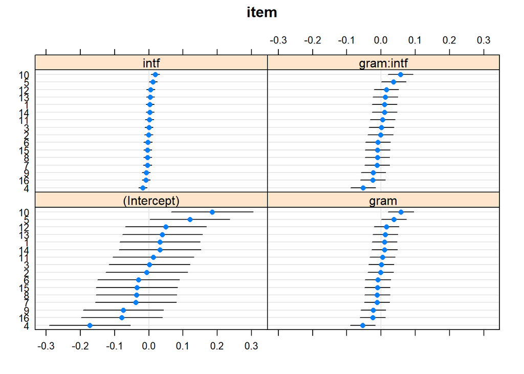

```r
print(dotplot(ranef(mod.e1.1,condVar=TRUE)))
```

#### 2.3.2 at postV1: interaction effect (grammaticality x interference)

Regression equation and predictions are same as for V1 region.

$\textbf{Results:}$

```r
data.postV1 <- subset(data.m,roi=='postV1')
mod.e1.3 <- lmer(log(value)~gram*intf+(1+gram*intf|subject)+(1+gram*intf|item),data=data.postV1, control=lmerControl(optimizer="optimx",optCtrl=list(method='nlminb')),REML = FALSE)
#save(mod.e1.3,'models/E1_postV1_gramxintf.Rda')
```

1. Fixed effect estimates

```r
apa_table(
  as.data.frame(summary(mod.e1.3)$coefficients)
  , caption = "Estimated effect of grammaticality and interference at post V1 region"
  , escape = FALSE
)
```

(#tab:unnamed-chunk-12)

*Estimated effect of grammaticality and interference at post V1 region*

|  | Estimate | Std. Error | t value |
| --- | --- | --- | --- |
| (Intercept) | 6.26 | 0.04 | 155.98 |
| gram | 0.18 | 0.02 | 7.38 |
| intf | 0.02 | 0.02 | 0.94 |
| gram:intf | 0.02 | 0.02 | 0.74 |

**There is a main effect of grammaticality at postV1 region, but no interaction effect.**

2. Residuals

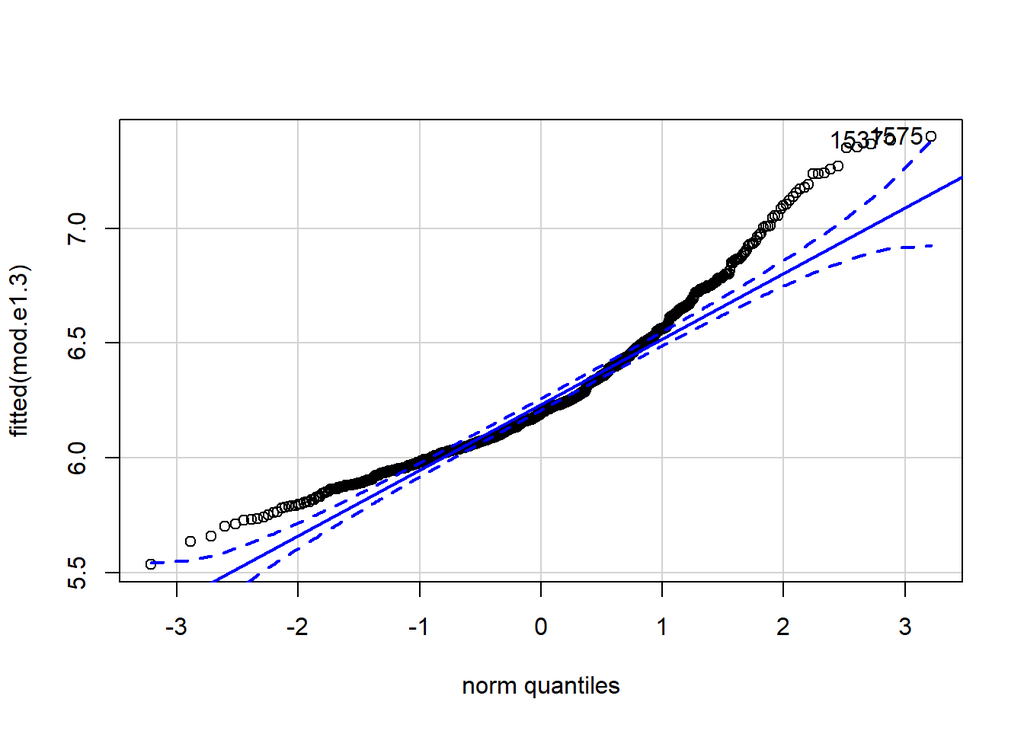

```
## 1575 1537
##  110  107
```

```r
# Let's check the residuals
qqPlot(fitted(mod.e1.3))
```

3. Participant-level differences

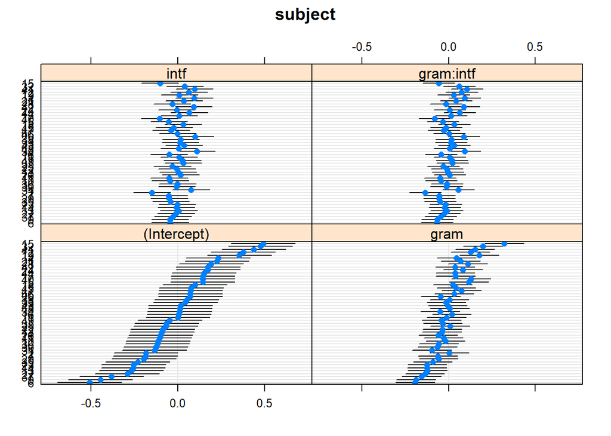

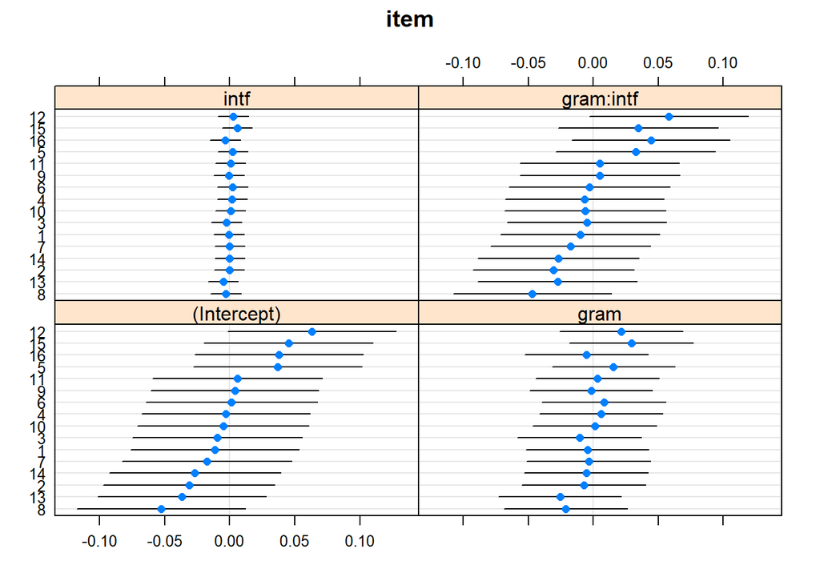

```r
print(dotplot(ranef(mod.e1.3,condVar=TRUE)))
```

### 2.4 Summary of Experiment 1

- Main effect of grammaticality at postV1 region (evidence for VP-forgetting hypothesis).
- No effect of grammaticality at V1 region
- No interaction effect between grammaticality and interference

## 3 Experiment 1a

Items of Experiment 1 were slightly modified to prevent three-verb sequences. Consider example (3).

1. The carpenter who the craftsman that the peasant had carried to the bus stop had hurt yesterday $supervised_{_{V1}}$ the apprentice.
2. The carpenter who the pillar that the peasant had carried to the bus stop had hurt yesterday $supervised_{_{V1}}$ the apprentice.
3. *The carpenter who the craftsman that the peasant had carried to the bus stop – $supervised_{_{V1}}$ the apprentice.
4. *The carpenter who the pillar that the peasant had carried to the bus stop – $supervised_{_{V1}}$ the apprentice.

### 3.1 Load the data of Experiment 1a

```
##   subject expt item condition position        word measure value  roi gram intf
## 1      36  gug    4         c        1         The      rt   298  NP1   -1    1
## 2      36  gug    4         c        2      trader      rt   281  NP1   -1    1
## 3      36  gug    4         c        3         who      rt   273  who   -1    1
## 4      36  gug    4         c        4         the      rt   234  NP2   -1    1
## 5      36  gug    4         c        5 businessman      rt   265  NP2   -1    1
## 6      36  gug    4         c        6        that      rt   272 that   -1    1
```

### 3.2 Visualize the data

#### 3.2.1 Mean and Confidence interval in grammatical vs. Ungrammatical conditions

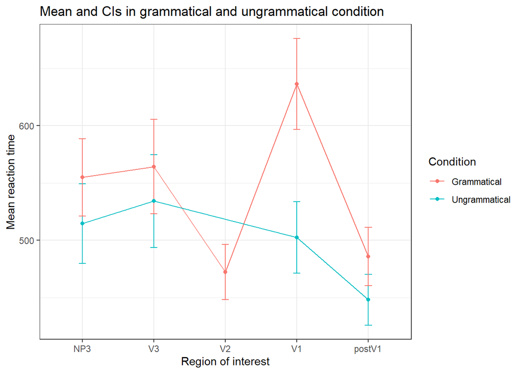

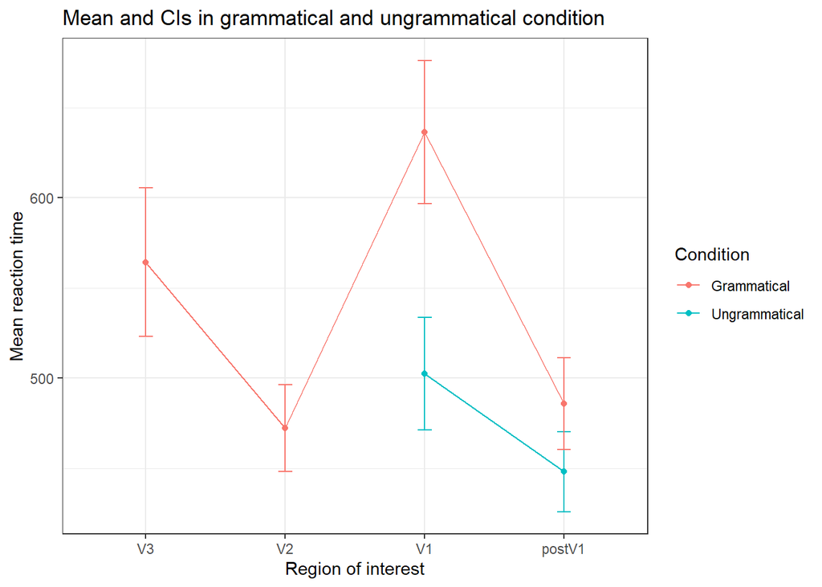

#### 3.2.2 Mean and Confidence interval in high vs. low interference conditions

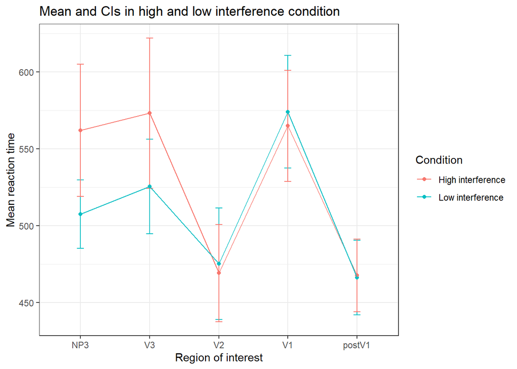

### 3.3 Analysis with linear mixed-effect models

The model and predictions are same as for Experiment 1 (see section 2.3).

#### 3.3.1 at V1: interaction effect (grammaticality x interference)

```r
data.V1 <- subset(data.m,roi=='V1')
mod.e1.1 <- lmer(log(value)~gram*intf+(1+gram*intf|subject)+(1+gram*intf|item),data=data.V1, control=lmerControl(optimizer="optimx",optCtrl=list(method='nlminb')))
#save(mod.e1.1,'models/E1_V1_gramxintf.Rda')
```

1. Fixed effect estimates

```r
apa_table(
  as.data.frame(summary(mod.e1.1)$coefficients)
  , caption = "Estimated effect of grammaticality and interference at V1 region"
  , escape = FALSE
)
```

(#tab:unnamed-chunk-20)

*Estimated effect of grammaticality and interference at V1 region*

|  | Estimate | Std. Error | t value |
| --- | --- | --- | --- |
| (Intercept) | 6.20 | 0.05 | 120.94 |
| gram | 0.10 | 0.02 | 5.62 |
| intf | 0.00 | 0.02 | -0.01 |
| gram:intf | 0.01 | 0.02 | 0.35 |

**Main effect of grammaticality at V1 region**

2. Residuals

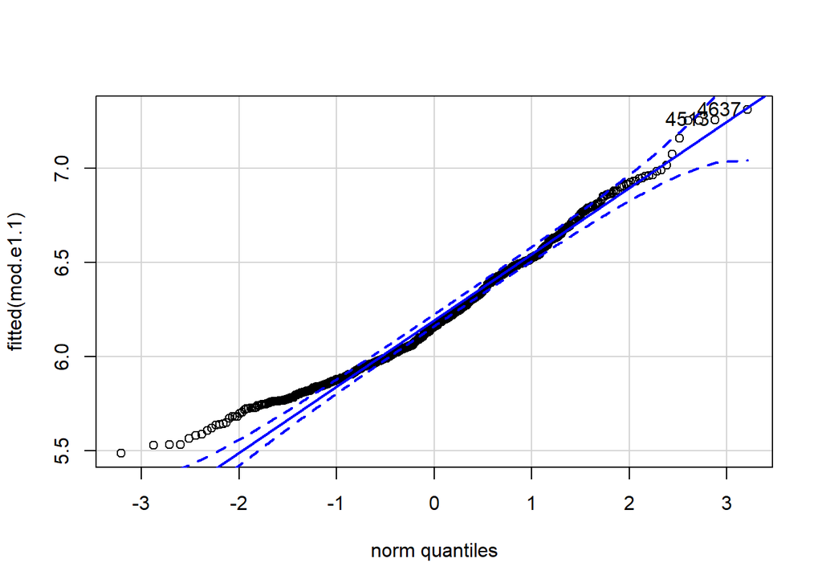

```
## 4637 4513
##  265  258
```

```r
# Let's check the residuals
qqPlot(fitted(mod.e1.1))
```

3. Participant-level differences

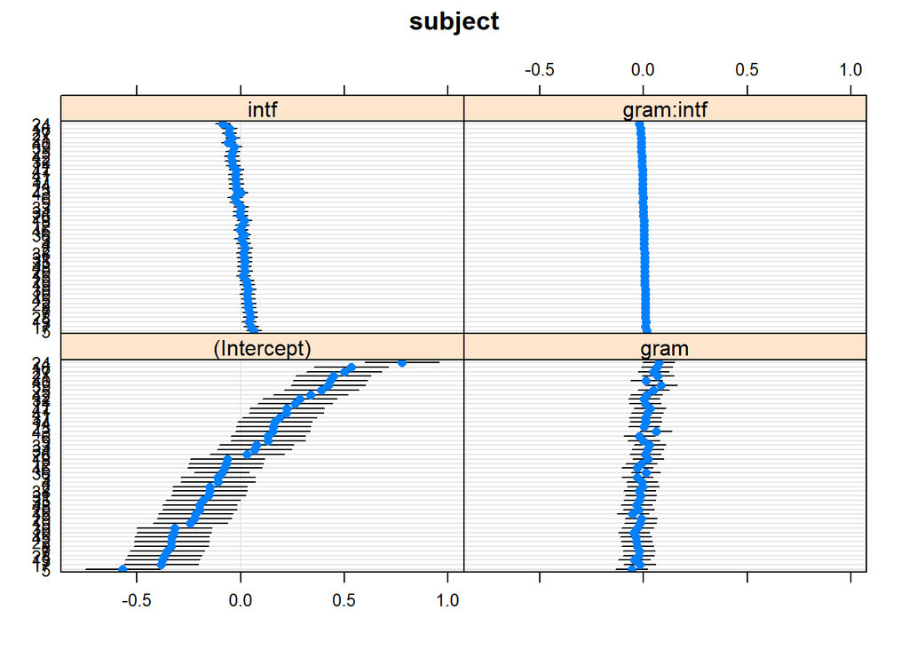

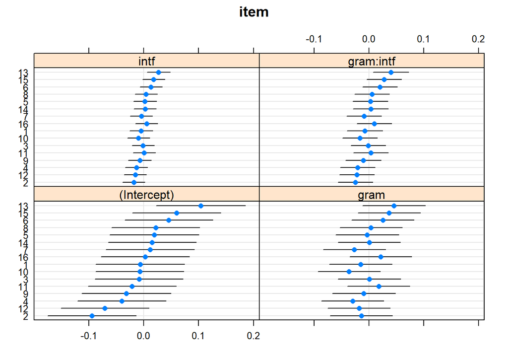

```r
print(dotplot(ranef(mod.e1.1,condVar=TRUE)))
```

#### 3.3.2 at postV1: interaction effect (grammaticality x interference)

```r
data.postV1 <- subset(data.m,roi=='postV1')
mod.e1.3 <- lmer(log(value)~gram*intf+(1+gram*intf|subject)+(1+gram*intf|item),data=data.postV1, control=lmerControl(optimizer="optimx",optCtrl=list(method='nlminb')))
#save(mod.e1.3,'models/E1_postV1_gramxintf.Rda')
```

1. Fixed effect estimates

```r
apa_table(
  as.data.frame(summary(mod.e1.3)$coefficients)
  , caption = "Estimated effect of grammaticality and interference at post V1 region"
  , escape = FALSE
)
```

(#tab:unnamed-chunk-24)

*Estimated effect of grammaticality and interference at post V1 region*

|  | Estimate | Std. Error | t value |
| --- | --- | --- | --- |
| (Intercept) | 6.07 | 0.03 | 182.38 |
| gram | 0.03 | 0.01 | 2.47 |
| intf | 0.00 | 0.01 | 0.26 |
| gram:intf | 0.01 | 0.01 | 0.93 |

**There is a main effect of grammaticality at postV1 region.**

2. Residuals

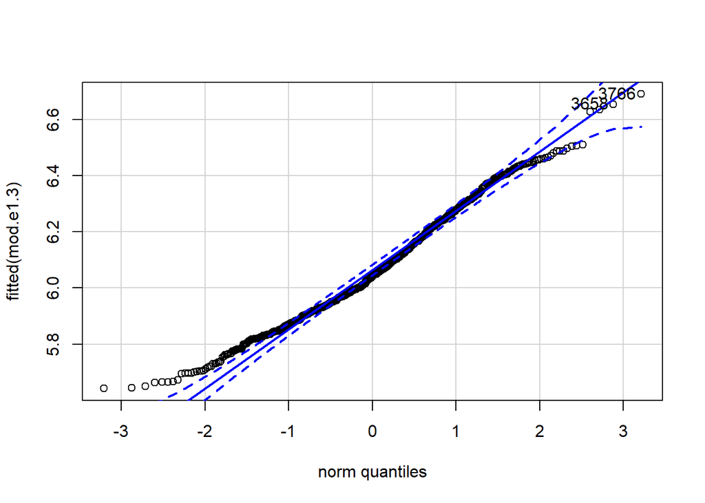

```
## 3766 3658
##  215  209
```

```r
# Let's check the residuals
qqPlot(fitted(mod.e1.3))
```

3. Participant-level differences

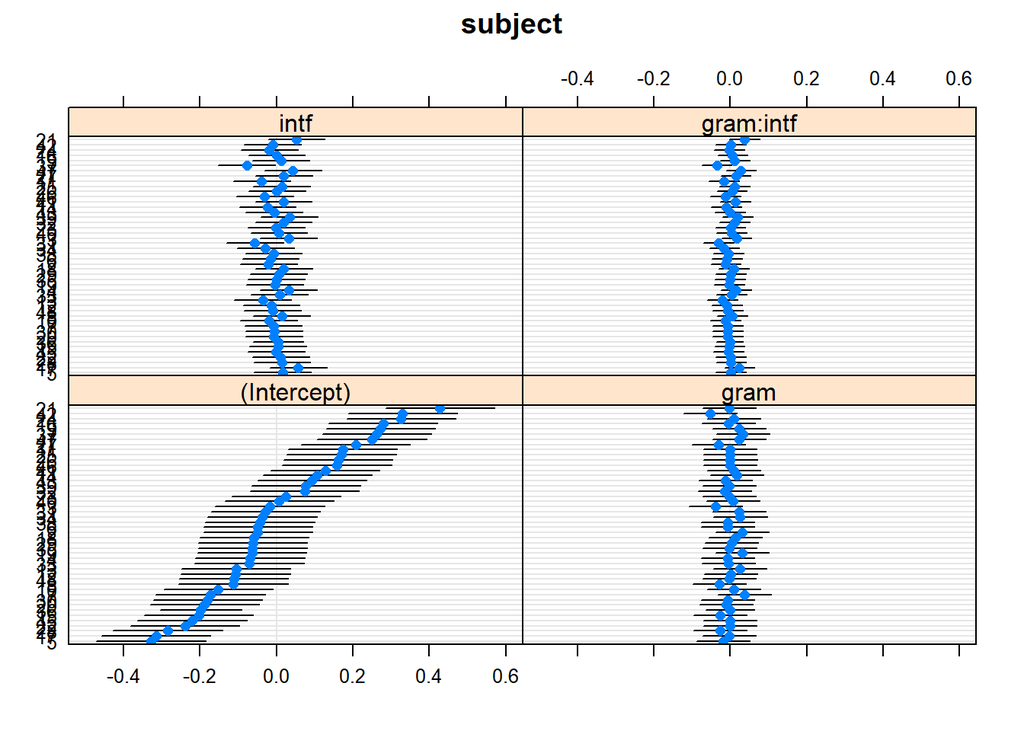

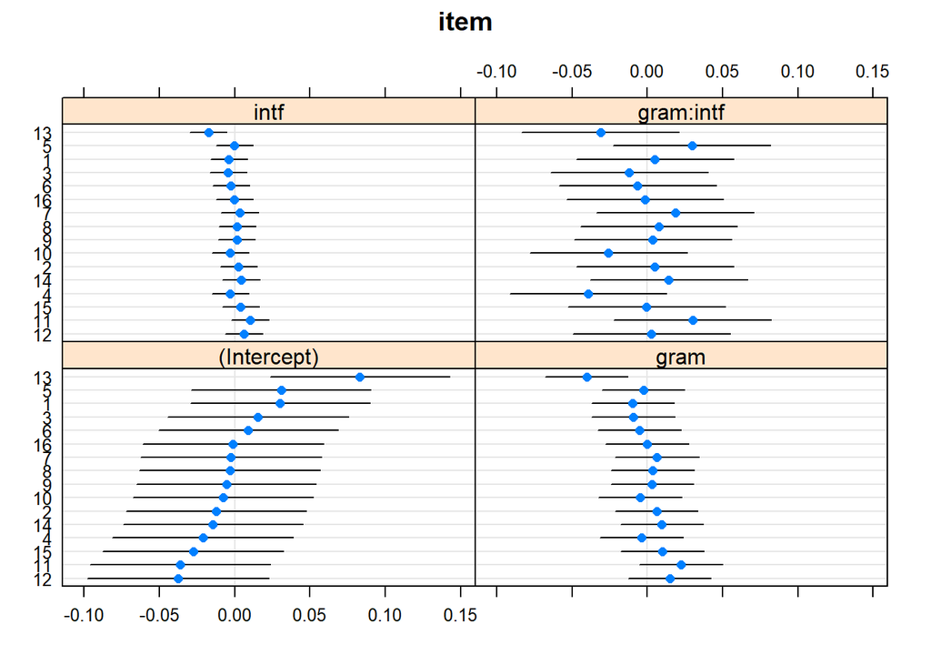

```r
print(dotplot(ranef(mod.e1.3,condVar=TRUE)))
```

### 3.4 Summary of Experiment 1a

- Main effect of grammaticality at both V1 and postV1 region.

## 4. Experiment 2

Experiment 2 was an eye-tracking study on English double center-embedding constructions. The items and predictions were same as in Experiment 1 (see section 2 for sample item and predictions).

### 4.1 Load the data

```r
head(data)
```

```
##   subject trial experiment item condition accuracy roi FFD FFP SFD FPRT RBRT
## 1       1     3        gug   16         d        1   1 144   1   0  260  260
## 2       1     3        gug   16         d        1   2 152   1   0  304  304
## 3       1     3        gug   16         d        1   3  48   1   0   76  256
## 4       1     3        gug   16         d        1   4 152   1   0  364  724
## 5       1     3        gug   16         d        1   5 332   1   0  332  332
## 6       1     3        gug   16         d        1   9 392   1   0  392  392
##    TFT  RPD CRPD  RRT RRTP RRTR FPRC TRC LPRT gram intf region
## 1  888  260  260  628    0  628    0   0  376   -1   -1    NP1
## 2 1672  304  564 1368    0 1368    0   0  456   -1   -1    who
## 3 1620  408  972 1544  180 1364    1   4  304   -1   -1    NP2
## 4 1064 1408 2380  700  360  340    1   3  140   -1   -1   that
## 5 1420  332 2712 1088    0 1088    0   2  156   -1   -1    NP3
## 6  712  392 3104  320    0  320    0   0  320   -1   -1     V3
```

```r
#Convert this into a long table with RRT as variable
data.m <- melt(data, id=c("subject","condition","item","accuracy","roi","gram","intf","region"),measure="RRT", variable.name="measure", na.rm=TRUE)
data.m <- subset(data.m,value>0)
head(data.m)
```

```
##   subject condition item accuracy roi gram intf region measure value
## 1       1         d   16        1   1   -1   -1    NP1     RRT   628
## 2       1         d   16        1   2   -1   -1    who     RRT  1368
## 3       1         d   16        1   3   -1   -1    NP2     RRT  1544
## 4       1         d   16        1   4   -1   -1   that     RRT   700
## 5       1         d   16        1   5   -1   -1    NP3     RRT  1088
## 6       1         d   16        1   9   -1   -1     V3     RRT   320
```

### 4.2 Visualize the data

#### 4.2.1 Mean and Confidence interval in grammatical vs. Ungrammatical conditions

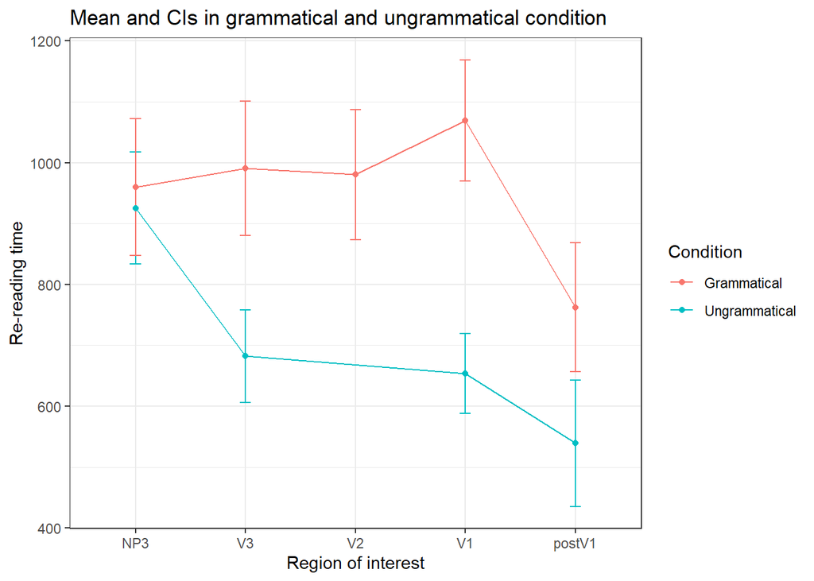

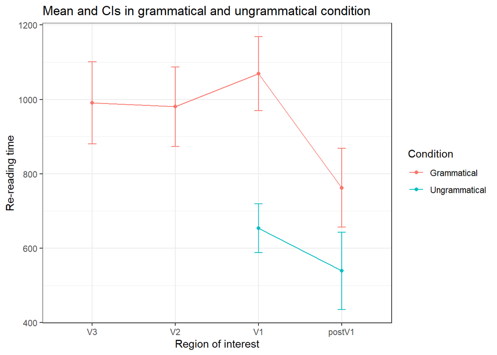

#### 4.2.2 Mean and Confidence interval in high vs. low interference conditions

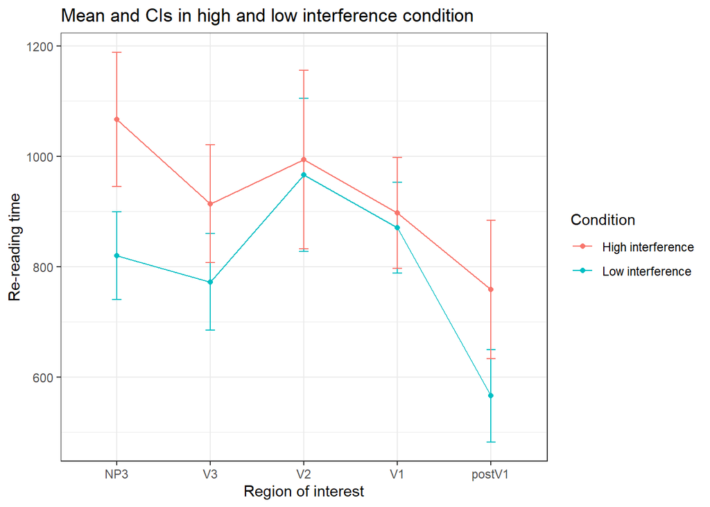

#### 4.2.3 Visualize by-subject data

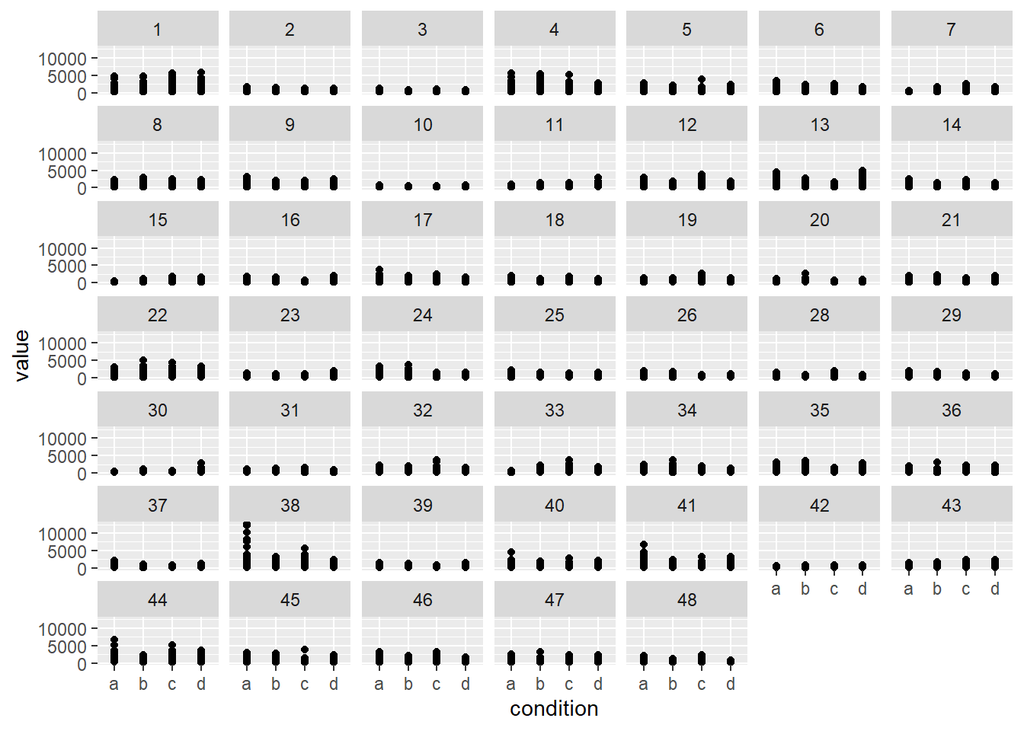

#### 4.2.4 Visualize by-item data

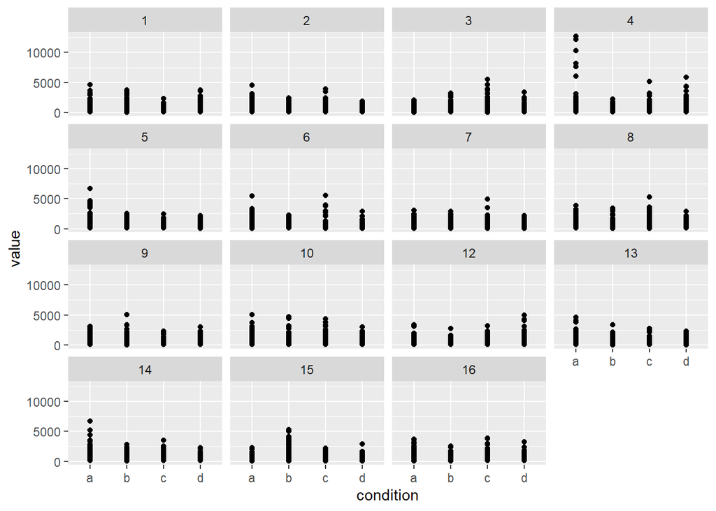

### 4.3 Analysis with linear mixed-effect models

#### 4.3.1 at V1: interaction effect (grammaticality x interference)

The model and the predictions are same as in Experiment 1 (see section 2.3.1).

**However, re-reading time (RRT) has been used as dependent variable here (see the paper for more details).**

**Results**

```r
data.V1 <- subset(data.m,region=='V1')
mod.e1.1 <- lmer(log(value)~gram*intf+(1+gram*intf|subject)+(1+gram*intf|item),data=data.V1, control=lmerControl(optimizer="optimx",optCtrl=list(method='nlminb')))
#save(mod.e1.1,'models/E1_V1_gramxintf.Rda')
```

1. Fixed effect estimates

```r
apa_table(
  as.data.frame(summary(mod.e1.1)$coefficients)
  , caption = "Estimated effect of grammaticality and interference at V1 region"
  , escape = FALSE
)
```

(#tab:unnamed-chunk-34)

*Estimated effect of grammaticality and interference at V1 region*

|  | Estimate | Std. Error | t value |
| --- | --- | --- | --- |
| (Intercept) | 6.40 | 0.06 | 108.21 |
| gram | 0.23 | 0.04 | 5.57 |
| intf | -0.01 | 0.04 | -0.18 |
| gram:intf | 0.04 | 0.03 | 1.12 |

**There is a main effect of grammaticality at V1 region.**

2. Residuals

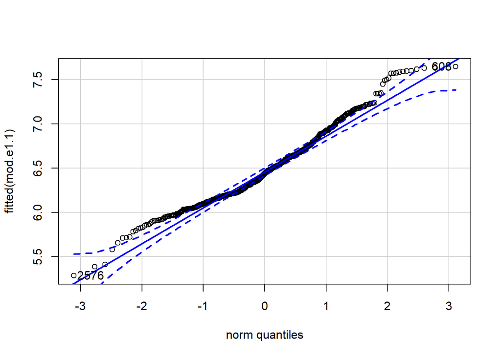

```
## 2576  608
##  163   37
```

```r
# Let's check the residuals
qqPlot(fitted(mod.e1.1))
```

3. Participant-level differences

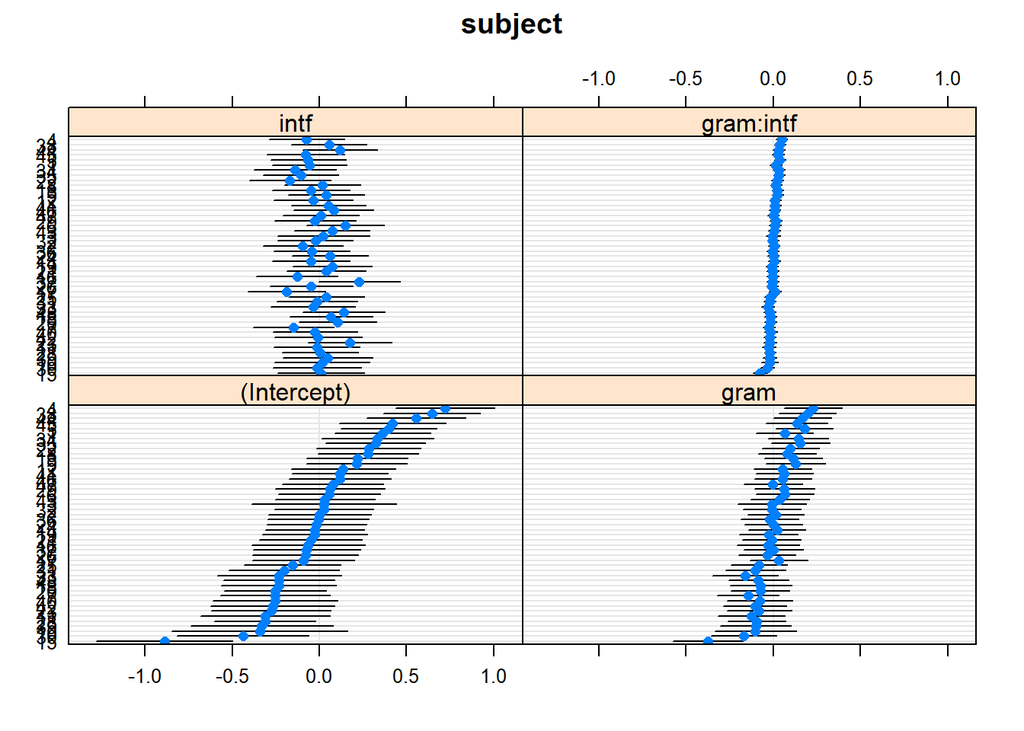

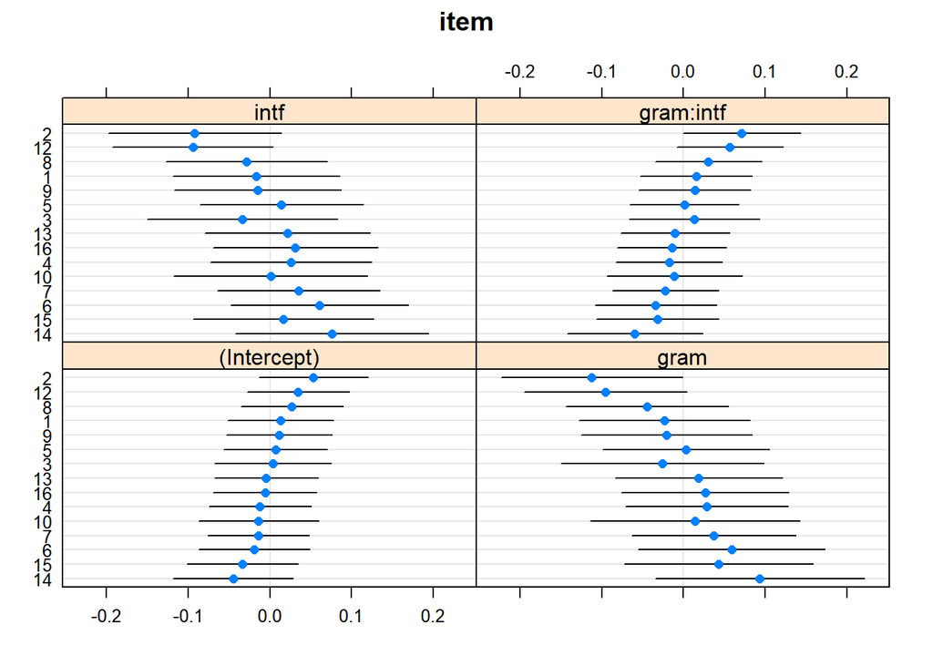

```r
print(dotplot(ranef(mod.e1.1,condVar=TRUE)))
```

#### 4.3.2 at postV1: interaction effect (grammaticality x interference)

$\textbf{Results:}$

```r
data.postV1 <- subset(data.m,region=='postV1')
mod.e1.3 <- lmer(log(value)~gram*intf+(1+gram*intf|subject)+(1+gram*intf|item),data=data.postV1, control=lmerControl(optimizer="optimx",optCtrl=list(method='nlminb')))
#save(mod.e1.3,'models/E1_postV1_gramxintf.Rda')
```

**There is a main effect of grammaticality at postV1 region**

1. Fixed effect estimates

```r
apa_table(
  as.data.frame(summary(mod.e1.3)$coefficients)
  , caption = "Estimated effect of grammaticality and interference at post V1 region"
  , escape = FALSE
)
```

(#tab:unnamed-chunk-38)

*Estimated effect of grammaticality and interference at post V1 region*

|  | Estimate | Std. Error | t value |
| --- | --- | --- | --- |
| (Intercept) | 5.79 | 0.15 | 38.99 |
| gram | 0.14 | 0.05 | 3.20 |
| intf | 0.08 | 0.04 | 1.74 |
| gram:intf | 0.00 | 0.05 | -0.10 |

2. Residuals

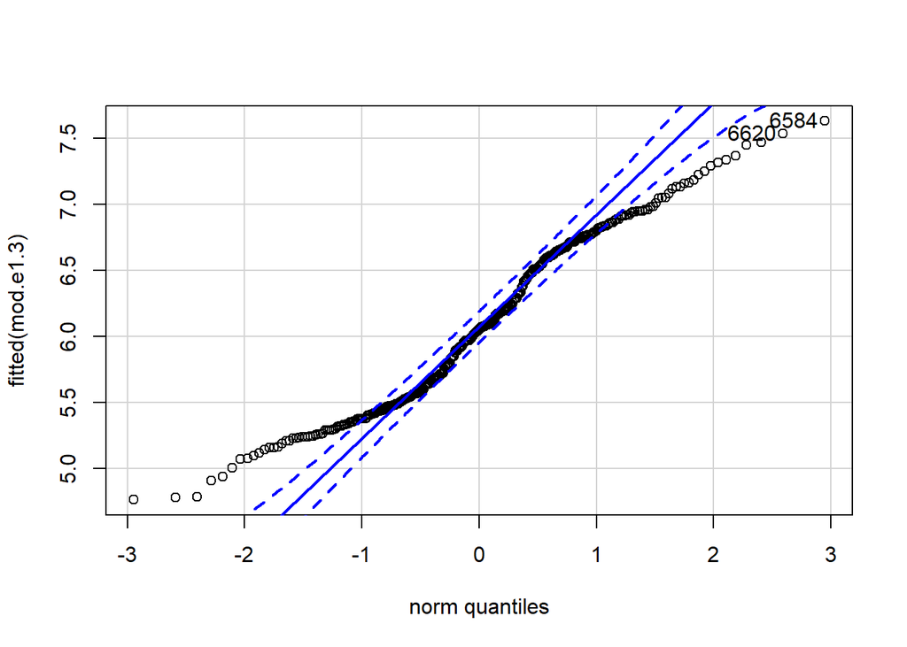

```
## 6584 6620
##  242  245
```

```r
# Let's check the residuals
qqPlot(fitted(mod.e1.3))
```

3. Participant-level differences

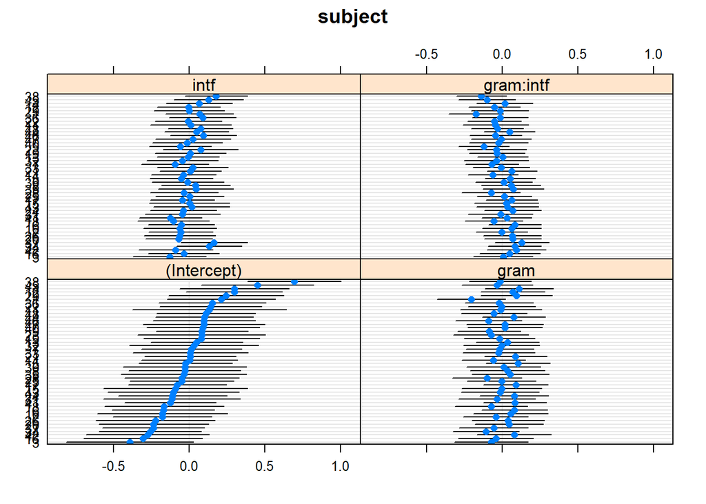

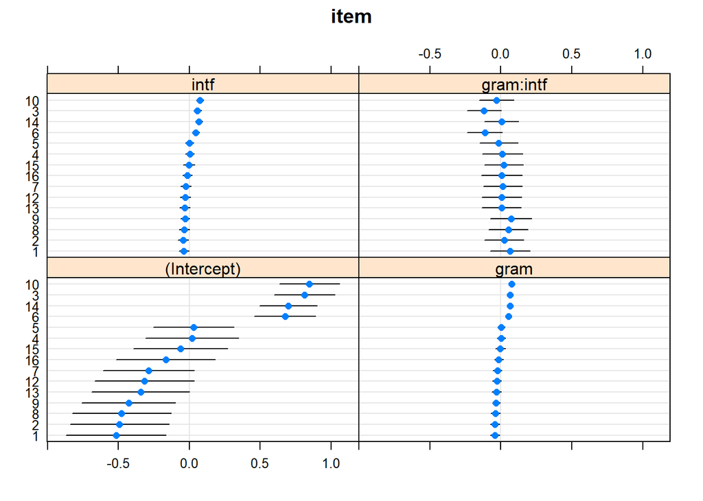

```r
print(dotplot(ranef(mod.e1.3,condVar=TRUE)))
```

### 4.4 Summary of Experiment 2

- Main effect of grammaticality on re-reading times at both V1 and postV1 region (evidence for VP-forgetting hypothesis).
- No interaction effect between grammaticality and interference.